# Analyse des Vins Blancs

```r
# Charger le jeu de données
winequality_white <- read_delim("dataset/winequality-white.csv", delim = ";", escape_double = FALSE, trim_ws = TRUE, show_col_types = FALSE)

# Normaliser les noms des colonnes
colnames(winequality_white) <- make.names(colnames(winequality_white))

print(colnames(winequality_white))
```

```
##  [1] "fixed.acidity"        "volatile.acidity"     "citric.acid"
##  [4] "residual.sugar"       "chlorides"            "free.sulfur.dioxide"
##  [7] "total.sulfur.dioxide" "density"              "pH"
## [10] "sulphates"            "alcohol"              "quality"
```

```r
# Afficher les dernières lignes du jeu de données
kable(tail(winequality_white))
```

| fixed.acidity | volatile.acidity | citric.acid | residual.sugar | chlorides | free.sulfur.dioxide | total.sulfur.dioxide | density | pH | sulphates | alcohol | quality |
| --- | --- | --- | --- | --- | --- | --- | --- | --- | --- | --- | --- |
| 6.5 | 0.23 | 0.38 | 1.3 | 0.032 | 29 | 112 | 0.99298 | 3.29 | 0.54 | 9.7 | 5 |
| 6.2 | 0.21 | 0.29 | 1.6 | 0.039 | 24 | 92 | 0.99114 | 3.27 | 0.50 | 11.2 | 6 |
| 6.6 | 0.32 | 0.36 | 8.0 | 0.047 | 57 | 168 | 0.99490 | 3.15 | 0.46 | 9.6 | 5 |
| 6.5 | 0.24 | 0.19 | 1.2 | 0.041 | 30 | 111 | 0.99254 | 2.99 | 0.46 | 9.4 | 6 |
| 5.5 | 0.29 | 0.30 | 1.1 | 0.022 | 20 | 110 | 0.98869 | 3.34 | 0.38 | 12.8 | 7 |
| 6.0 | 0.21 | 0.38 | 0.8 | 0.020 | 22 | 98 | 0.98941 | 3.26 | 0.32 | 11.8 | 6 |

```r
# Statistiques descriptives
summary(winequality_white)
```

```
##  fixed.acidity    volatile.acidity  citric.acid     residual.sugar
##  Min.   : 3.800   Min.   :0.0800   Min.   :0.0000   Min.   : 0.600
##  1st Qu.: 6.300   1st Qu.:0.2100   1st Qu.:0.2700   1st Qu.: 1.700
##  Median : 6.800   Median :0.2600   Median :0.3200   Median : 5.200
##  Mean   : 6.855   Mean   :0.2782   Mean   :0.3342   Mean   : 6.391
##  3rd Qu.: 7.300   3rd Qu.:0.3200   3rd Qu.:0.3900   3rd Qu.: 9.900
##  Max.   :14.200   Max.   :1.1000   Max.   :1.6600   Max.   :65.800
##    chlorides       free.sulfur.dioxide total.sulfur.dioxide    density
##  Min.   :0.00900   Min.   :  2.00      Min.   :  9.0        Min.   :0.9871
##  1st Qu.:0.03600   1st Qu.: 23.00      1st Qu.:108.0        1st Qu.:0.9917
##  Median :0.04300   Median : 34.00      Median :134.0        Median :0.9937
##  Mean   :0.04577   Mean   : 35.31      Mean   :138.4        Mean   :0.9940
##  3rd Qu.:0.05000   3rd Qu.: 46.00      3rd Qu.:167.0        3rd Qu.:0.9961
##  Max.   :0.34600   Max.   :289.00      Max.   :440.0        Max.   :1.0390
##        pH          sulphates         alcohol         quality
##  Min.   :2.720   Min.   :0.2200   Min.   : 8.00   Min.   :3.000
##  1st Qu.:3.090   1st Qu.:0.4100   1st Qu.: 9.50   1st Qu.:5.000
##  Median :3.180   Median :0.4700   Median :10.40   Median :6.000
##  Mean   :3.188   Mean   :0.4898   Mean   :10.51   Mean   :5.878
##  3rd Qu.:3.280   3rd Qu.:0.5500   3rd Qu.:11.40   3rd Qu.:6.000
##  Max.   :3.820   Max.   :1.0800   Max.   :14.20   Max.   :9.000
```

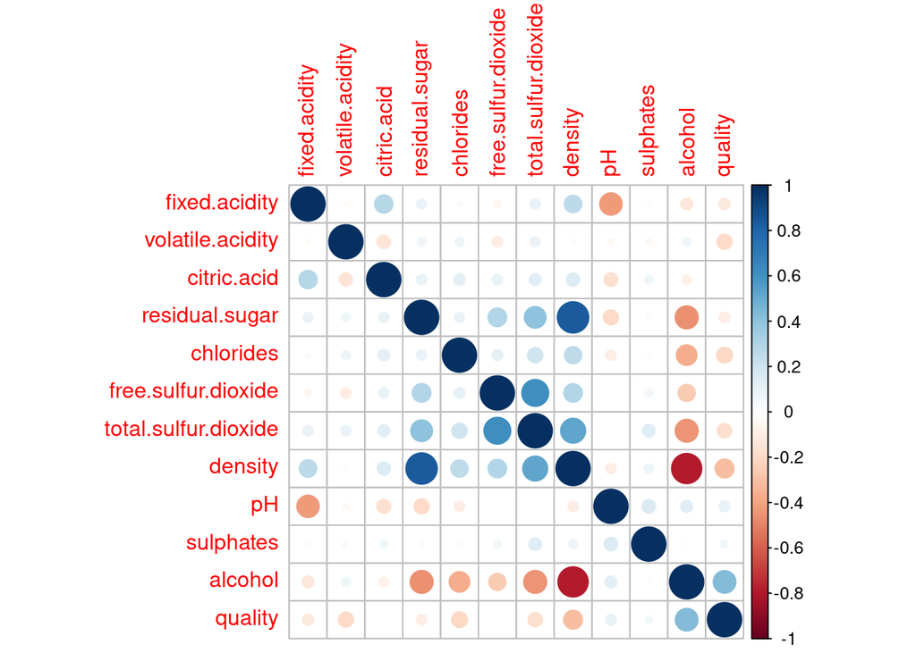

```r
# Calculer la matrice de corrélation
correlation_matrix <- cor(winequality_white)

# Visualiser la matrice de corrélation
corrplot(correlation_matrix, method = "circle")
```

### Interpreting the results:

This correlation plot shows clearly the correlations between variables.

- A positive correlation (shades of blue) means that if one the variables’ value increases, the other increases.
- A negative correlation (shades of red) means that if one of the variables’ value increases, the other decreases.

Obviously, wine density is inversely correlated to alcohol content. This can be easily understood when comparing the density of ethanol to that of water:

- Ethanol density : 0.7892 g/mL at 20°C.
- Water density : 0.9982 g/mL at 20°C.

And indeed, if alcohol content is higher, the density lowers, which explains the strong negative correlation.

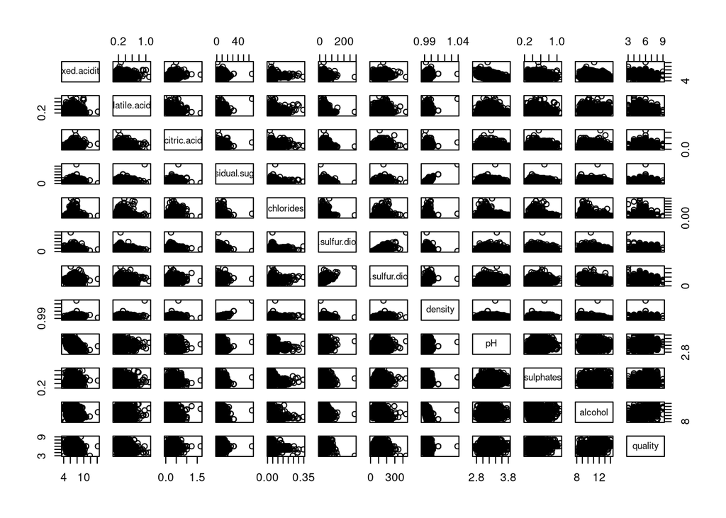

```r
# Calculer la matrice de corrélation
correlation_pairs_matrix <- pairs(winequality_white)
```

```r
# Test de normalité (Shapiro-Wilk)
shapiro.test(winequality_white$quality)
```

```
##
##  Shapiro-Wilk normality test
##
## data:  winequality_white$quality
## W = 0.88904, p-value < 2.2e-16
```

```r
# Créer une variable binaire pour la qualité
winequality_white$quality_binary <- ifelse(winequality_white$quality >= 6, "Good", "Bad")

# Effectuer le test t de Student
t.test(`alcohol` ~ quality_binary, data = winequality_white)
```

```
##
##  Welch Two Sample t-test
##
## data:  alcohol by quality_binary
## t = -32.495, df = 4389.8, p-value < 2.2e-16
## alternative hypothesis: true difference in means between group Bad and group Good is not equal to 0
## 95 percent confidence interval:
##  -1.0596430 -0.9390554
## sample estimates:
##  mean in group Bad mean in group Good
##            9.84953           10.84888
```

```r
# Séparer les données en ensembles d'entraînement et de test
set.seed(123)
trainIndex <- createDataPartition(winequality_white$quality, p = .8,
                                  list = FALSE,
                                  times = 1)
wineTrain <- winequality_white[ trainIndex,]
wineTest  <- winequality_white[-trainIndex,]

wineTrain <- wineTrain[, !(names(wineTrain) %in% c("quality_binary"))]

dim(wineTrain)
```

```
## [1] 3919   12
```

```r
dim(wineTest)
```

```
## [1] 979  13
```

## Decision Tree Model

```r
# Entraîner le modèle avec un seul arbre de décision
tree_model <- rpart(quality ~ ., data = wineTrain, method = "class")

# Afficher l'arbre de décision
print(tree_model)
```

```
## n= 3919
##
## node), split, n, loss, yval, (yprob)
##       * denotes terminal node
##
##  1) root 3919 2160 6 (0.0046 0.032 0.3 0.45 0.18 0.035 0.001)
##    2) alcohol< 10.625 2299 1296 6 (0.0048 0.041 0.43 0.44 0.079 0.012 0.00043)
##      4) volatile.acidity>=0.2375 1455  673 5 (0.0048 0.056 0.54 0.36 0.038 0.0027 0.00069)
##        8) alcohol< 9.85 992  384 5 (0.005 0.053 0.61 0.3 0.027 0.001 0) *
##        9) alcohol>=9.85 463  237 6 (0.0043 0.06 0.38 0.49 0.063 0.0065 0.0022)
##         18) free.sulfur.dioxide< 24.5 150   78 5 (0 0.13 0.48 0.33 0.047 0.0067 0) *
##         19) free.sulfur.dioxide>=24.5 313  137 6 (0.0064 0.026 0.33 0.56 0.07 0.0064 0.0032) *
##      5) volatile.acidity< 0.2375 844  365 6 (0.0047 0.017 0.24 0.57 0.15 0.027 0) *
##    3) alcohol>=10.625 1620  864 6 (0.0043 0.019 0.12 0.47 0.33 0.067 0.0019)
##      6) alcohol< 12.55 1334  670 6 (0.0045 0.022 0.13 0.5 0.29 0.054 0.0015) *
##      7) alcohol>=12.55 286  142 7 (0.0035 0.007 0.031 0.32 0.5 0.13 0.0035) *
```

```r
# Faire des prédictions sur l'ensemble de test
tree_predictions <- predict(tree_model, wineTest, type = "class")

# Afficher les prédictions
head(tree_predictions)
```

```
## 1 2 3 4 5 6
## 6 5 6 6 5 6
## Levels: 3 4 5 6 7 8 9
```

```r
# Calculer la précision
accuracy <- sum(tree_predictions == wineTest$quality) / nrow(wineTest)

# Afficher la précision
print(paste("Précision :", round(accuracy * 100, 2), "%"))
```

```
## [1] "Précision : 51.89 %"
```

```r
y_true <- ifelse(wineTest$quality_binary == "Good", 1, 0)

# Convertir les facteurs en numériques
tree_predictions_numeric <- as.numeric(as.character(tree_predictions))

# Convertir les scores de qualité en probabilités
probabilities <- tree_predictions_numeric / 10

# Fonction pour calculer le log loss
log_loss <- function(y_true, probabilities, eps=1e-15){
  probabilities <- pmin(pmax(probabilities, eps), 1 - eps)
  -mean(y_true * log(probabilities) + (1 - y_true) * log(1 - probabilities))
}

# Calcul de la log loss
ll_rf <- log_loss(y_true, probabilities)
print(ll_rf)
```

```
## [1] 0.6150915
```

## Random Forest Model

```r
# Entraîner le modèle de forêts aléatoires
model <- randomForest(quality ~ ., data = wineTrain)

# Prédire sur l'ensemble de test
predictions <- predict(model, wineTest)

# Arrondir les prédictions pour obtenir des nombres entiers
rounded_predictions <- round(predictions)

# Afficher les prédictions
head(rounded_predictions)
```

```
## 1 2 3 4 5 6
## 6 6 6 6 6 6
```

```r
# Évaluer le modèle
eval <- postResample(pred = rounded_predictions, obs = wineTest$quality)

# Afficher les métriques d'évaluation
eval
```

```
##      RMSE  Rsquared       MAE
## 0.6580995 0.4600931 0.3677222
```

```r
# Calculer la précision
accuracy <- sum(rounded_predictions == wineTest$quality) / nrow(wineTest)

# Afficher la précision
print(paste("Précision :", round(accuracy * 100, 2), "%"))
```

```
## [1] "Précision : 66.29 %"
```

```r
# Importer les variables importantes
importance(model)
```

```
##                      IncNodePurity
## fixed.acidity             183.2601
## volatile.acidity          315.3653
## citric.acid               197.2069
## residual.sugar            221.2184
## chlorides                 243.9526
## free.sulfur.dioxide       306.5367
## total.sulfur.dioxide      238.8863
## density                   336.3713
## pH                        203.3838
## sulphates                 176.8777
## alcohol                   486.6842
```

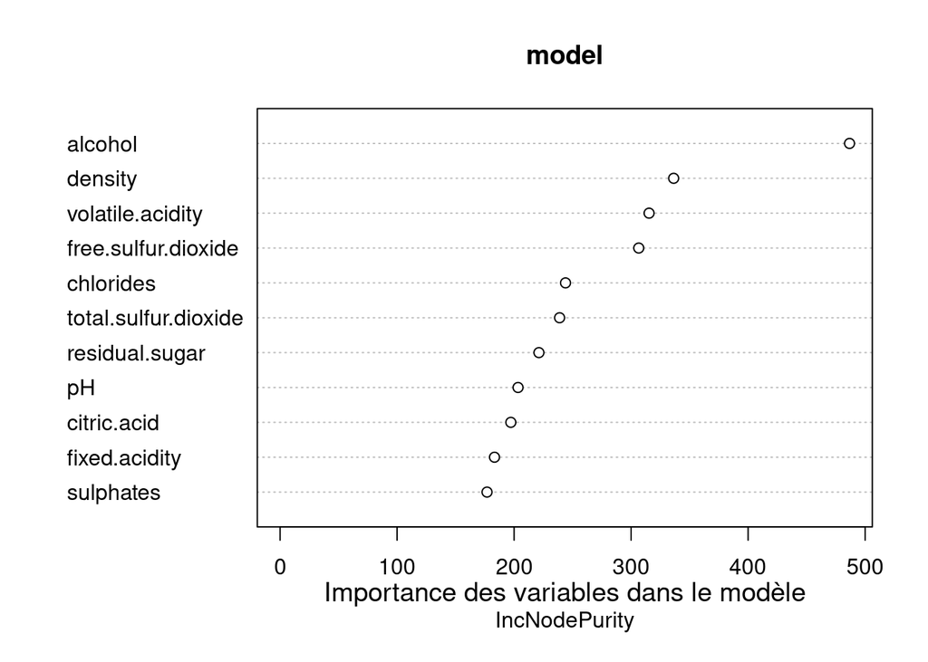

```r
varImpPlot(model)
mtext("Importance des variables dans le modèle", side = 1, line = 2, cex = 1.2)
```

Dans cette section, nous avons entraîné un modèle de forêts aléatoires pour prédire la qualité du vin.

```r
# y_true = 0 ou 1
y_true <- ifelse(wineTest$quality_binary == "Good", 1, 0)

# Convertir les scores de qualité en probabilités
probabilities <- rounded_predictions / 10

# Fonction pour calculer le log loss
log_loss <- function(y_true, probabilities, eps=1e-15){
  probabilities <- pmin(pmax(probabilities, eps), 1 - eps)
  -mean(y_true * log(probabilities) + (1 - y_true) * log(1 - probabilities))
}

# Calcul de la log loss
ll_rf <- log_loss(y_true, probabilities)
print(ll_rf)
```

```
## [1] 0.5808852
```

Le log loss binaire est une mesure de performance utilisée pour évaluer la précision des prédictions probabilistes d’un modèle de classification binaire, en comparant les probabilités prédites à la véritable classe (0 ou 1) de chaque échantillon.

## Interprétation

### RMSE

Le RMSE mesure l’écart moyen entre les valeurs prédites par le modèle et les valeurs réelles. Une valeur de RMSE plus faible indique un meilleur ajustement du modèle aux données. Ici, la valeur est de 0.6581, ce qui signifie qu’en moyenne, les prédictions du modèle s’écartent de 0.6581 unités des valeurs réelles.

### Rsquared

Le coefficient de détermination, ou R-squared, représente la proportion de la variance de la variable dépendante qui est prévisible à partir des variables indépendantes. Un R-squared de 1 signifie que le modèle explique parfaitement la variance des données, tandis qu’un R-squared de 0 signifie que le modèle n’explique aucune variance. Ici, la valeur est de 0.4601, indiquant que le modèle explique environ 46.01% de la variance dans la qualité du vin.

### MAE

Le MAE mesure l’erreur moyenne absolue entre les prédictions et les valeurs réelles. Contrairement au RMSE, il ne pénalise pas autant les grandes erreurs. Ici, la valeur est de 0.3677, ce qui signifie qu’en moyenne, les prédictions du modèle s’écartent de 0.3677 unités des valeurs réelles.

- **Importance des variables** : Nous avons examiné l’importance des différentes variables dans le modèle. Les variables avec des scores d’importance élevés contribuent davantage aux prédictions.
- **Visualisation** : Le graphique d’importance des variables nous permet de voir rapidement quelles caractéristiques sont les plus influentes dans la prédiction de la qualité du vin.